# Survival Analysis Notes

## 5. Outlier detection and missing value imputation

### Introduction to Missing data handling

1. General Categories of Missing Data
- MCAR - Mising completely at random
  - NAs are present due to randomness
  - Deleting or replacing the NAs does not cause bias
- MAR - Missing at random
  - NAs were produced for a random reason
  - The reason has nothing to do with the observation
  - Standard imputation methods can solve the issue
- MNAR - Missing not at random
  - NAs are present for a reason
  - Some observations cannot be captured properly
  - The NAs cause correption in the analysis
2. Simple methods for missing data handling
- Deleting: Amount of NAs is <5% and they are MCAR
- Hot deck imputation: Replacing NAs with another abservation (eg. LOCF); can cause bias.
- Imputation with mean: Replacing NAs with the mean results in less bias
- Interpolation: replacement is identified via a predefined algorithm.
- Problem: they do not account for uncertainty
3. Multiple imputation methods
- Calculate m number of values as replacement
- A copy of the dataset for each set of replacements is generated
- Analysis is performed on each copy
- Average, variance and confidence intervals are taken from the pool
- They work on MAR and MNAR datasets too
- MICE- multiple imputation by Chained Equations

### Simple methods for missing data handling

1. Use a function with a built-in NA handling feature

```r
library(readr)
FlowerPicks <- read_csv("FlowerPicks.csv",
                        col_types = cols(X1 = col_skip()))
### Missing Data Handling

# Use FlowerPicks csv - remove ID column

summary(FlowerPicks)
```

```
##     Player              Score             Time
##  Length:5501        Min.   : 334.0   Min.   : 3.00
##  Class :character   1st Qu.: 544.0   1st Qu.: 9.00
##  Mode  :character   Median : 658.0   Median :14.00
##                     Mean   : 672.5   Mean   :14.13
##                     3rd Qu.: 789.0   3rd Qu.:20.00
##                     Max.   :2366.0   Max.   :25.00
##                     NA's   :13       NA's   :14
```

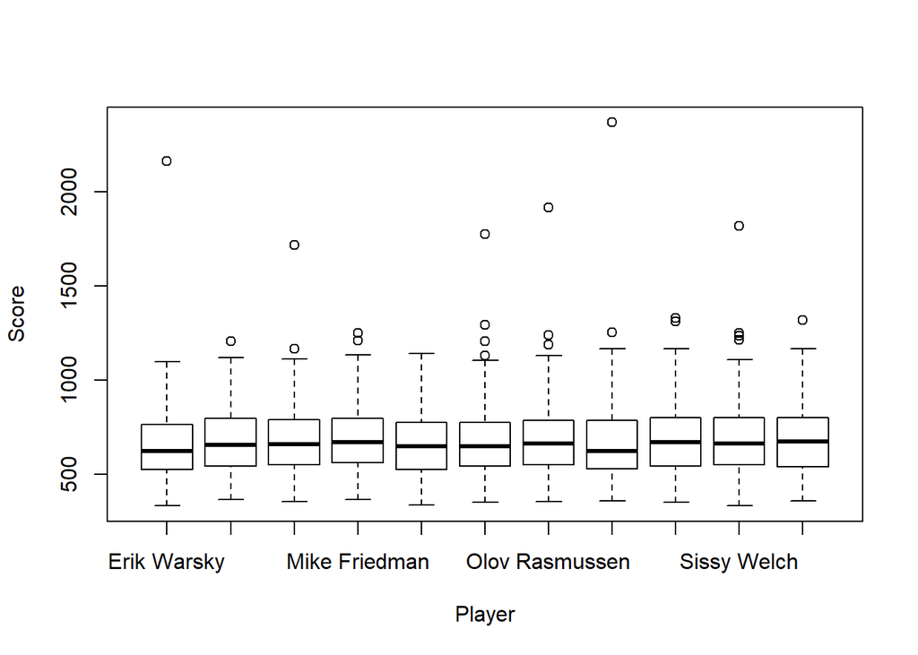

```r
# Vector with complete cases

compcases <- complete.cases(FlowerPicks) == T

# Per default R ignores missing data - na.action argument

boxplot(Score ~ Player,FlowerPicks)
```

```r
lm(data = FlowerPicks, formula = Score ~ Time)
```

```
##
## Call:
## lm(formula = Score ~ Time, data = FlowerPicks)
##
## Coefficients:
## (Intercept)         Time
##    665.6469       0.5099
```

2. Use a basic function dedicated to NA handling

```r
# Using na.omit to remove al rows with an NA

cleandata <- na.omit(FlowerPicks)

summary(cleandata)
```

```
##     Player              Score             Time
##  Length:5475        Min.   : 334.0   Min.   : 3.00
##  Class :character   1st Qu.: 544.0   1st Qu.: 9.00
##  Mode  :character   Median : 658.0   Median :14.00
##                     Mean   : 672.8   Mean   :14.12
##                     3rd Qu.: 789.0   3rd Qu.:20.00
##                     Max.   :2366.0   Max.   :25.00
```

```r
# Data lost several rows - only 5475 observations
```

3. Use an advanced imputation tool
- Library(zoo): Functions for missing data handling from the library “zoo”
  - na.fill(): fill NA with value you provide manually and not recommendated unless there is strong reason.
  - na.locf(): Take the value before the NA and replace it.
  - na.spline(): linear interpolation to produce replacement.
  - na.approx(): linear interpolation to produce replacement.
  - na.aggregate(): take the mean for NA replacement

```r
# zoo for column wise operations

library(zoo)
x = na.locf(FlowerPicks$Score)
summary(x)
```

```
##    Min. 1st Qu.  Median    Mean 3rd Qu.    Max.
##   334.0   544.0   658.0   672.4   789.0  2366.0
```

- Check the presence of NAs with summary()
- Identifying complete observations with complete.cases()
- Function with a built-in NA handling feature:
  - e.g. “na.action=” argument -> omitting NAs
- Functions for omitting/ deleting NAs from the data:
  - e.g. na.omit()
- Simple imputation methods:
  - The na.x() functions from the library “zoo”

### Missing data implementation with machine learning

- Using machine learning algorithms for missing data handling
- Complex yet effective method
- Library “mice”
  - various multiple imputation methods
  - Dependency packages
- Dataset: FlowerPicks
- Multiple imputation method work with the whole data.frame

```r
## Machine Learning for NA removal

library(mice)
```

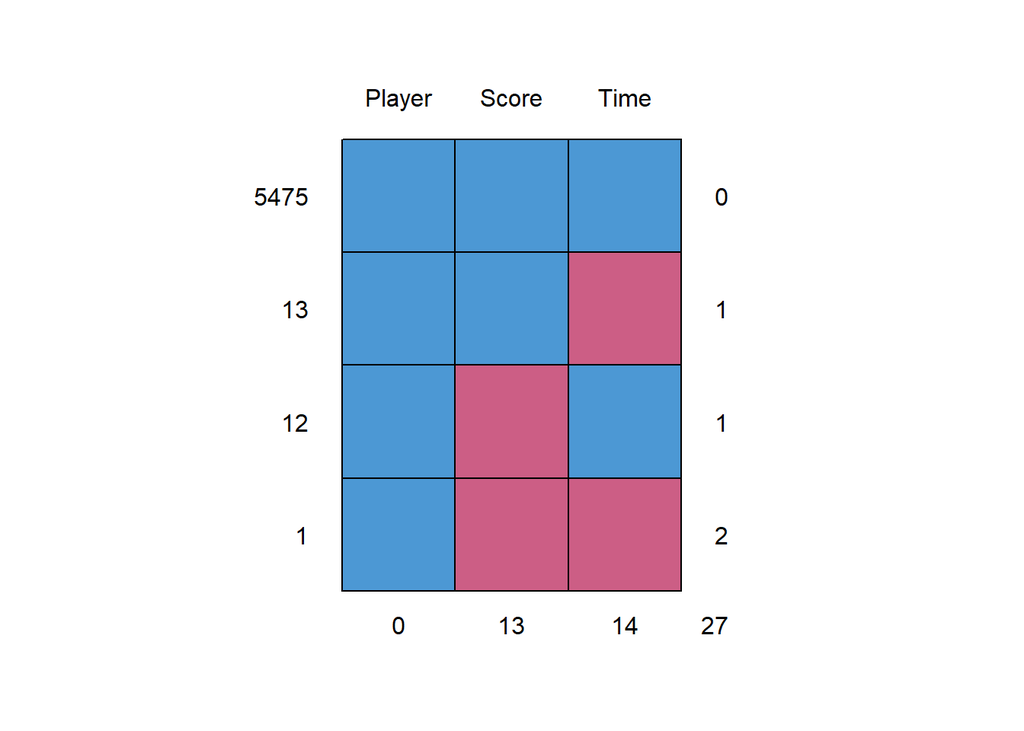

```
##      Player Score Time
## 5475      1     1    1  0
## 13        1     1    0  1
## 12        1     0    1  1
## 1         1     0    0  2
##           0    13   14 27
```

```r
# Distribution of the missing values

md.pattern(FlowerPicks)
```

```r
# 1 row has 2 NAs
```

```r
# Using the mice function

mymice <- mice(FlowerPicks,
               m = 10, # number of imputation
               method = "rf") # random forest
# The result has class mids

class(mymice)
```

```
## [1] "mids"
```

library(mice)

- Complex package = many dependencies
- Dependencies are usually installed by default
- Further packages might also be required for particular tasks eg.
  - Library(lattice) for plotting tasks
  - Library(randomForest) for random forest models
- install those packages on demand

```r
# Display the calculated data

mymice$imp$Score
```

```
##        1   2   3    4   5    6   7   8   9  10
## 34   914 574 548  524 408  675 624 789 617 942
## 43   541 564 756  748 642  802 540 558 605 447
## 233  577 886 638  650 644  872 725 844 665 452
## 435  473 740 624  698 604  789 506 580 453 574
## 456  507 684 645  544 499  687 709 438 434 468
## 463  545 552 895  776 758  411 764 764 814 625
## 555  828 698 619 1013 625 1013 394 486 698 625
## 1500 687 789 607  625 670  907 632 670 878 731
## 3346 470 886 863  911 828  625 374 429 407 548
## 3434 561 678 872  776 393  457 612 789 408 606
## 3453 504 558 895  886 740  872 504 544 684 891
## 3465 607 645 694  620 675  552 571 710 382 581
## 5443 596 548 645  709 692  668 564 844 556 436
```

```r
# Fill the NAs

mymicecomplete <- complete(mymice, 5)

summary(mymicecomplete)
```

```
##     Player              Score             Time
##  Length:5501        Min.   : 334.0   Min.   : 3.00
##  Class :character   1st Qu.: 544.0   1st Qu.: 9.00
##  Mode  :character   Median : 658.0   Median :14.00
##                     Mean   : 672.4   Mean   :14.12
##                     3rd Qu.: 789.0   3rd Qu.:20.00
##                     Max.   :2366.0   Max.   :25.00
```

```r
# Analysis with m variations of the dataset

lmfit <- with(mymice, lm(Score ~ Time))

# Pooling the results

summary(pool(lmfit))
```

```
##          term    estimate std.error  statistic       df   p.value
## 1 (Intercept) 665.2009045 5.7619133 115.447921 5385.955 0.0000000
## 2        Time   0.5136113 0.3728551   1.377509 5364.377 0.1684124
```

Workflow

- Mulitple imputation methods with library(mice)
- Creating 10 versions of the missing values with the function mice()
  - Method = random forest ML algorithm
1. selecting one version of the imputation values with the function complete()
- Creating m versions of the model with the function with()
- Extracting the average of the model parameters with the function pool()

### Statistical outliers

1. Ourliers
- Deleting and exchanging the outlier has drawbacks with small samples
- Assumption: the data point is faulty
- An outlier totally out of scale might be wrong measurement
  - Not likely when measurements are automated
  - Human mistakes are more likely to occur
  - Example: plausibility checks in clinical research
- Outlier can be valid measurements and they might reveal hidden potentials
2. Three sigma edit rule (to detect the outlier)
- Calculates an interval around the mean
  - Mean + t * SD
  - Mean - t * SD
- Data is to be expected within the range; Outlier: data outside the range
- Common method in quality control
- T=3 -> for normally distributed data the probability of observing a value more than three standard deviations from the mean is 0.3%
- Caution: both mean and standard deviation are sensitive to the presence of outliers.
3. Boxplot method
- The lower and upper quartiles of the boxplot provide the interval borders
  - Q1-c * IQD
  - Q3-c * IQD
- IQD = Q3 - Q1 -> Interquartile distance
- C = 1.5 -> Most commonly used value
- Less sensitive to the presence of outliers.
4. Advanced methods for multivariate data
- Model based method
  - Fit the appropriate model to the dataset
  - Data points outside the model are outliers
  - Models based on deviation, probability statisctis or depth
- Proximity based method
  - Calculates the distance of the data points
  - Significantly different proximity measure is considered as an ourlier.
5. Outliers in data visualization
- Mark the outliers with different colors or shapes
- Boxplots are visually the most suitable
- Scatterplot: values need to be separated
- Some R and Python packages support outlier identification
  - Library(mvoutlier) in R

### Detecting outliers in univariate datasets

1. Outlier detection : Univariate

Use a stats tests + distance measure approach

- ESD method:
  - Mean + t * SD
  - Mean - t * SD
- Boxplot method
- Tests from library(outliers)

```r
# [mean - t * SD, mean + t * SD]

x = c(rnorm(10), 150); x
```

```
##  [1]   0.8969861   0.1535430   0.7044762  -0.9488494   3.4899482   1.0377803
##  [7]   1.6056354  -0.5813290  -0.6293500  -2.1471722 150.0000000
```

```r
t = 3 # range
m = mean(x)
s = sd(x)

b1 = m - s*t; b1
```

```
## [1] -121.4677
```

```r
b2 = m + s*t; b2
```

```
## [1] 149.3916
```

```r
y = ifelse(x >= b1 & x <= b2, 0, 1); y # outlier identifier
```

```
##  [1] 0 0 0 0 0 0 0 0 0 0 1
```

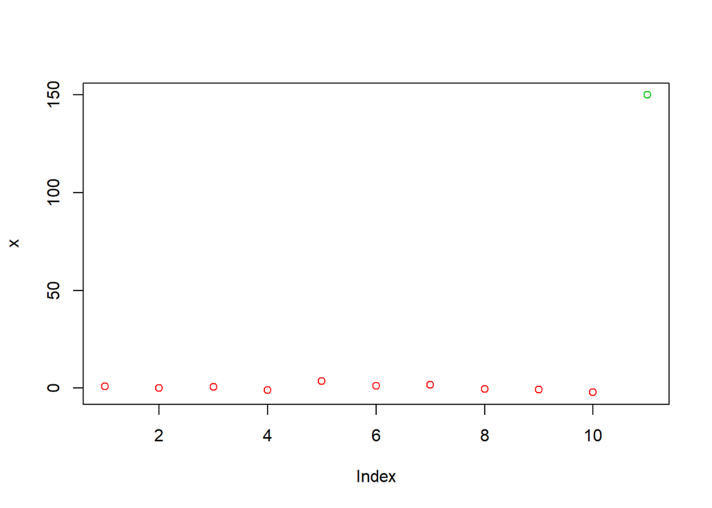

```r
plot(x, col=y+2)
```

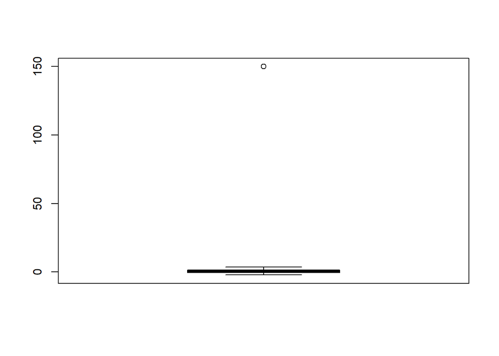

```r
# simple boxplot

boxplot(x)
```

```r
boxplot.stats(x) # give outliers
```

```
## $stats
## [1] -2.1471722 -0.6053395  0.7044762  1.3217079  3.4899482
##
## $n
## [1] 11
##
## $conf
## [1] -0.2135459  1.6224983
##
## $out
## [1] 150
```

```r
# package outliers

library(outliers)

dixon.test(x)
```

```
##
##  Dixon test for outliers
##
## data:  x
## Q = 0.98308, p-value < 2.2e-16
## alternative hypothesis: highest value 150 is an outlier
```

```r
grubbs.test(x, type = 11, two.sided = T) # type 11 for 2 sides, opossite
```

```
##
##  Grubbs test for two opposite outliers
##
## data:  x
## G = 3.37032181, U = 0.00074326, p-value = 0.8134
## alternative hypothesis: -2.14717216613054 and 150 are outliers
```

2. Multivariate methods
- Library(mvoutliers)
  - Methods
    - sign1, sign2 and pcout calculate the distance between data points while relying on principle analysis
  - Exercise datasets
  - Plot
    - Visualizing multivariate datasets.

```r
### advanced techniques for multivariate data

library(mvoutlier)
elements = data.frame(Hg = moss$Hg, Fe = moss$Fe, Al = moss$Al, Ni = moss$Ni)
head(elements)
```

```
##      Hg    Fe    Al    Ni
## 1 0.044  96.5  71.2  4.45
## 2 0.062 359.0 245.0 18.10
## 3 0.069 122.0 103.0  4.05
## 4 0.077 350.0 307.0 37.00
## 5 0.062 395.0 253.0  1.60
## 6 0.052 698.0 238.0 34.90
```

```r
myout = sign1(elements[,1:4], qqcrit = 0.975); myout
```

```
## $wfinal01
##   [1] 1 1 1 0 1 0 1 1 0 1 1 1 1 0 0 1 1 1 1 1 0 1 1 1 1 1 0 1 0 1 1 1 1 1 1 0 1
##  [38] 0 1 1 1 1 1 1 0 0 1 0 1 0 1 1 1 1 1 0 1 0 0 1 1 1 1 1 1 1 1 1 1 1 1 1 1 1
##  [75] 0 0 1 1 1 1 1 1 0 1 1 1 1 1 1 1 1 1 1 1 1 1 0 1 1 1 1 1 1 0 1 0 0 1 1 1 0
## [112] 1 1 1 1 1 1 1 1 1 1 1 0 0 1 1 1 1 0 1 1 1 1 0 0 1 1 0 1 1 1 0 1 1 1 0 1 1
## [149] 1 1 0 1 1 0 0 1 1 1 0 0 0 1 0 1 1 1 1 1 1 1 1 1 1 1 1 0 0 1 1 1 1 1 1 1 1
## [186] 1 0 1 1 1 1 1 1 1 1 1 1 0 0 1 1 1 1 1 1 1 0 1 1 1 1 0 1 1 1 1 1 1 1 1 1 1
## [223] 1 1 0 1 1 1 1 1 1 1 1 1 1 0 1 1 0 0 1 1 1 1 1 1 0 0 1 1 1 0 0 1 0 1 1 1 1
## [260] 1 1 1 1 1 0 1 1 1 0 1 0 1 1 1 1 1 1 1 0 1 1 1 1 1 1 1 0 1 1 1 0 0 1 1 1 1
## [297] 0 1 1 1 1 1 1 0 1 1 1 1 1 0 1 0 1 1 1 1 1 1 0 0 0 1 1 1 1 1 1 1 0 0 1 1 1
## [334] 1 1 1 1 0 1 1 1 1 1 1 0 1 1 1 1 1 1 1 1 1 1 1 1 1 1 1 1 1 1 0 1 1 1 1 1 1
## [371] 1 1 1 1 1 1 0 1 1 1 0 1 0 0 0 1 1 1 1 0 0 1 1 1 0 1 0 1 1 1 0 1 1 1 0 1 0
## [408] 1 0 1 0 0 1 1 1 1 0 1 1 1 1 1 1 1 1 1 0 0 1 1 1 1 1 0 1 1 1 1 1 1 1 1 0 1
## [445] 1 1 1 0 1 1 0 1 1 1 1 1 1 1 1 1 1 1 0 1 1 0 0 1 1 1 1 1 1 1 1 1 1 1 1 1 1
## [482] 1 0 1 1 1 1 1 0 1 1 1 1 1 1 1 1 0 0 1 1 1 0 1 1 1 1 1 1 1 1 0 0 1 1 1 1 1
```

[output cut: 108 more lines]

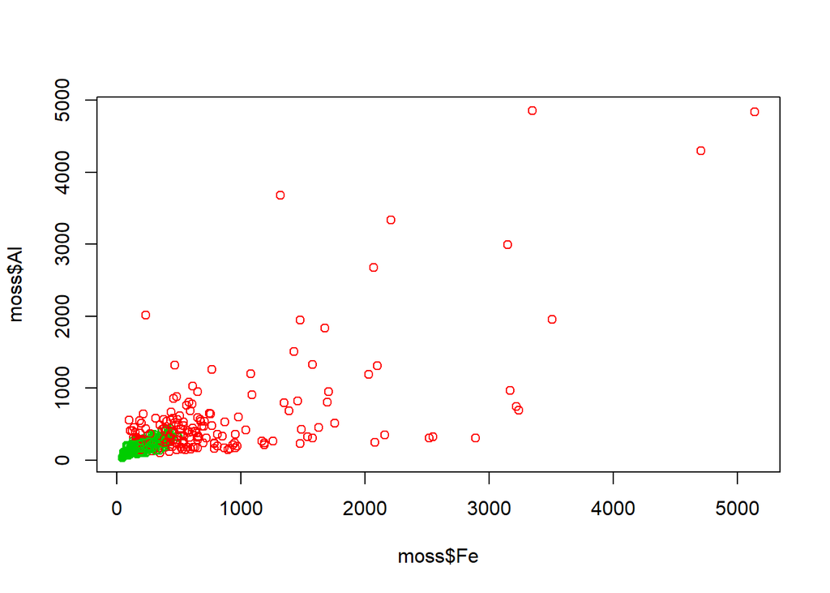

```r
myout = pcout(elements[,1:4])

plot(moss$Fe, moss$Al, col=myout$wfinal01+2)
```

```r
# red points are ourliers
```

### Exercise:

Missing data imputation and outlier detection

Dataset: mgus from “survival”

1. Eliminate the two columns featuring too many missing values
2. Test the column “creat” for outliers and replace the outliers with NA or a marker
3. Replace the missing values and outliers with suitable values

```r
## Exercise Missing Data with mgus

library(survival)
data(mgus)
head(mgus)
```

```
##   id age    sex dxyr pcdx pctime futime death alb creat  hgb mspike
## 1  1  78 female   68 <NA>     NA    748     1 2.8   1.2 11.5    2.0
## 2  2  73 female   66   LP   1310   6751     1  NA    NA   NA    1.3
## 3  3  87   male   68 <NA>     NA    277     1 2.2   1.1 11.2    1.3
## 4  4  86   male   69 <NA>     NA   1815     1 2.8   1.3 15.3    1.8
## 5  5  74 female   68 <NA>     NA   2587     1 3.0   0.8  9.8    1.4
## 6  6  81   male   68 <NA>     NA    563     1 2.9   0.9 11.5    1.8
```

```r
str(mgus)
```

```
## 'data.frame':    241 obs. of  12 variables:
##  $ id    : num  1 2 3 4 5 6 7 8 9 10 ...
##  $ age   : num  78 73 87 86 74 81 72 79 85 58 ...
##   ..- attr(*, "label")= chr "AGE AT date_on"
##  $ sex   : Factor w/ 2 levels "female","male": 1 1 2 2 1 2 1 1 1 2 ...
##   ..- attr(*, "label")= chr "Sex"
##  $ dxyr  : num  68 66 68 69 68 68 68 69 70 65 ...
##  $ pcdx  : Factor w/ 4 levels "AM","LP","MA",..: NA 2 NA NA NA NA NA NA NA NA ...
##  $ pctime: num  NA 1310 NA NA NA NA NA NA NA NA ...
##   ..- attr(*, "label")= chr "Progression to Group 4 (days)"
##  $ futime: num  748 6751 277 1815 2587 ...
##   ..- attr(*, "label")= chr "Follow-Up Time"
##  $ death : num  1 1 1 1 1 1 1 1 1 1 ...
##  $ alb   : num  2.8 NA 2.2 2.8 3 2.9 3 3.1 3.2 3.5 ...
##   ..- attr(*, "label")= chr "Serum Albumin"
##  $ creat : num  1.2 NA 1.1 1.3 0.8 0.9 0.8 0.8 1 1 ...
##   ..- attr(*, "label")= chr "Serum Creatinine"
##  $ hgb   : num  11.5 NA 11.2 15.3 9.8 11.5 13.5 15.5 12.4 14.8 ...
##   ..- attr(*, "label")= chr "Hemoglobin"
##  $ mspike: num  2 1.3 1.3 1.8 1.4 1.8 1.3 1.4 1.5 2.2 ...
##   ..- attr(*, "label")= chr "Serum M-Spike"
##  - attr(*, "formats")=List of 1
##   ..$ death:List of 2
##   .. ..$ values: num  0 1
##   .. ..$ labels: chr  "Alive" "Dead"
```

```r
summary(mgus)
```

```
##        id           age            sex           dxyr        pcdx
##  Min.   :  1   Min.   :34.00   female:104   Min.   :56.0   AM  :  8
##  1st Qu.: 61   1st Qu.:55.00   male  :137   1st Qu.:66.0   LP  :  5
##  Median :121   Median :63.00                Median :68.0   MA  :  7
##  Mean   :121   Mean   :62.87                Mean   :67.4   MM  : 44
##  3rd Qu.:181   3rd Qu.:72.00                3rd Qu.:70.0   NA's:177
##  Max.   :241   Max.   :90.00                Max.   :73.0
##
##      pctime          futime          death             alb
##  Min.   :  365   Min.   :    6   Min.   :0.0000   Min.   :1.800
##  1st Qu.: 2469   1st Qu.: 2422   1st Qu.:1.0000   1st Qu.:2.900
##  Median : 3778   Median : 5022   Median :1.0000   Median :3.200
##  Mean   : 4342   Mean   : 5425   Mean   :0.9336   Mean   :3.204
##  3rd Qu.: 5750   3rd Qu.: 8264   3rd Qu.:1.0000   3rd Qu.:3.500
##  Max.   :11685   Max.   :14325   Max.   :1.0000   Max.   :5.100
##  NA's   :177                                      NA's   :31
##      creat            hgb            mspike
##  Min.   :0.600   Min.   : 7.40   Min.   :0.300
##  1st Qu.:0.900   1st Qu.:12.20   1st Qu.:1.500
##  Median :1.000   Median :13.20   Median :1.700
##  Mean   :1.095   Mean   :13.15   Mean   :1.764
##  3rd Qu.:1.100   3rd Qu.:14.50   3rd Qu.:2.000
##  Max.   :6.400   Max.   :16.60   Max.   :3.200
##  NA's   :43      NA's   :1
```

```r
# Removing columns

mgusnew = mgus[,-c(5,6)]

# Statistical test for outliers

library(outliers)

grubbs.test(mgusnew$creat, type = 10)
```

```
##
##  Grubbs test for one outlier
##
## data:  mgusnew$creat
## G = 9.43249, U = 0.54607, p-value < 2.2e-16
## alternative hypothesis: highest value 6.4 is an outlier
```

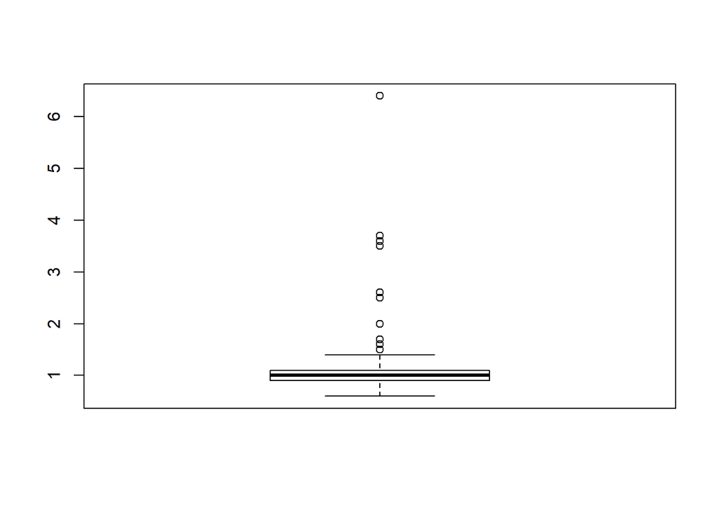

```r
boxplot(mgusnew$creat)
```

```r
# Identify and replace all values above threshold

x = which(mgusnew$creat > 2.5)

mgusnew$creat[x] = NA

# Check the column maximum

summary(mgusnew)
```

```
##        id           age            sex           dxyr          futime
##  Min.   :  1   Min.   :34.00   female:104   Min.   :56.0   Min.   :    6
##  1st Qu.: 61   1st Qu.:55.00   male  :137   1st Qu.:66.0   1st Qu.: 2422
##  Median :121   Median :63.00                Median :68.0   Median : 5022
##  Mean   :121   Mean   :62.87                Mean   :67.4   Mean   : 5425
##  3rd Qu.:181   3rd Qu.:72.00                3rd Qu.:70.0   3rd Qu.: 8264
##  Max.   :241   Max.   :90.00                Max.   :73.0   Max.   :14325
##
##      death             alb            creat            hgb
##  Min.   :0.0000   Min.   :1.800   Min.   :0.600   Min.   : 7.40
##  1st Qu.:1.0000   1st Qu.:2.900   1st Qu.:0.900   1st Qu.:12.20
##  Median :1.0000   Median :3.200   Median :1.000   Median :13.20
##  Mean   :0.9336   Mean   :3.204   Mean   :1.021   Mean   :13.15
##  3rd Qu.:1.0000   3rd Qu.:3.500   3rd Qu.:1.100   3rd Qu.:14.50
##  Max.   :1.0000   Max.   :5.100   Max.   :2.500   Max.   :16.60
##                   NA's   :31      NA's   :48      NA's   :1
##      mspike
##  Min.   :0.300
##  1st Qu.:1.500
##  Median :1.700
##  Mean   :1.764
##  3rd Qu.:2.000
##  Max.   :3.200
##
```

```r
# NA replacement with mice

library(mice)

mymice <- mice(mgusnew, m = 3, method = "norm")
mymicecomplete <- complete(mymice, 3)

summary(mymicecomplete)
```

```
##        id           age            sex           dxyr          futime
##  Min.   :  1   Min.   :34.00   female:104   Min.   :56.0   Min.   :    6
##  1st Qu.: 61   1st Qu.:55.00   male  :137   1st Qu.:66.0   1st Qu.: 2422
##  Median :121   Median :63.00                Median :68.0   Median : 5022
##  Mean   :121   Mean   :62.87                Mean   :67.4   Mean   : 5425
##  3rd Qu.:181   3rd Qu.:72.00                3rd Qu.:70.0   3rd Qu.: 8264
##  Max.   :241   Max.   :90.00                Max.   :73.0   Max.   :14325
##      death             alb           creat             hgb
##  Min.   :0.0000   Min.   :1.80   Min.   :0.4206   Min.   : 7.40
##  1st Qu.:1.0000   1st Qu.:2.90   1st Qu.:0.9000   1st Qu.:12.20
##  Median :1.0000   Median :3.20   Median :1.0000   Median :13.20
##  Mean   :0.9336   Mean   :3.19   Mean   :1.0326   Mean   :13.16
##  3rd Qu.:1.0000   3rd Qu.:3.50   3rd Qu.:1.1674   3rd Qu.:14.50
##  Max.   :1.0000   Max.   :5.10   Max.   :2.5000   Max.   :16.60
##      mspike
##  Min.   :0.300
##  1st Qu.:1.500
##  Median :1.700
##  Mean   :1.764
##  3rd Qu.:2.000
##  Max.   :3.200
```